# Student Engagement in SPGA 2025/26: In-Person Attendance and Online Learning

### 3.3.2 Access across departments

[figure not shown]

[figure not shown]

### 3.3.3 Access across resource types

Breaking coverage down by resource type reveals differences in the extent to which students engage with different categories of material. **Assessment Guidance** resources tend to show the highest median coverage: a large proportion of students access most or all of the assignment-related materials posted to a module, reflecting the universal pressure to engage with marking criteria, rubrics, and submission guidance regardless of other engagement habits. **Lecture Slides** also show relatively high median coverage, consistent with their role as a core reference point that most students return to at some point during or after the teaching period. By contrast, **Linked Learning Resources** — external readings and library links — show notably lower and more dispersed coverage, suggesting that students are selective about which readings they access and that many items on the reading list go unclicked. **Learning Activities** such as worksheets and seminar briefs sit at an intermediate level, with wide variability indicating that some students engage thoroughly with preparatory materials while others do not. **Lecture Capture and Pre-Recorded Video** — which include both live session recordings and pre-recorded video packages — show highly variable coverage, likely reflecting the mix of students who use them for review and those who rely on them as a substitute for missed sessions. Across all types, the interquartile ranges are wide, underscoring that individual behaviour varies considerably even within the same module and resource category.

## 3.4 When do students access learning resources on Moodle?

### 3.4.1 Frequency of access across days and weeks of the term

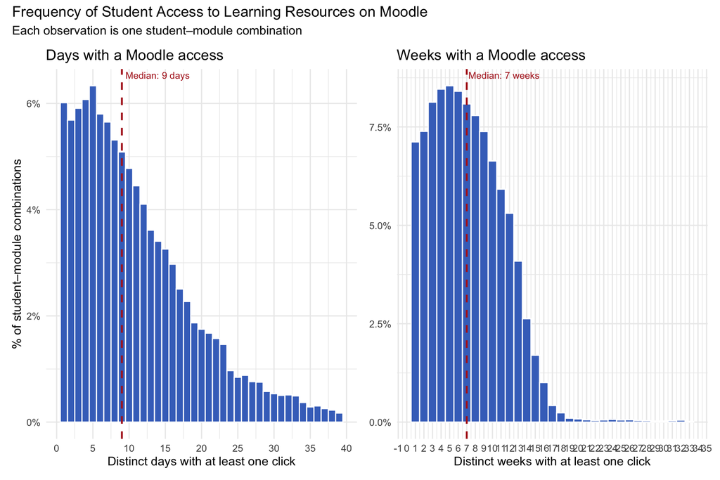

With 10 weeks of teaching per module, a student engaging consistently throughout the term would be expected to access Moodle in all 10 weeks and on roughly 10 to 20 distinct days (assuming one to two access days per week). The median lines in each panel provide a useful reference point.

On the days dimension, the distribution is right-skewed and the median sits in the lower range of what would be expected for regular engagement (10–20 days). This suggests that, while most students access Moodle across most weeks, they tend to do so on just one day per week on average — with a smaller but visible group returning multiple times per week, producing the long tail beyond 20 days. Together, the two panels paint a picture of engagement that concentrated in intensity (typically just one access day per week), with a subset of students who engage more intensively, likely revisiting resources in the run-up to assessments.

### 3.4.2 Moodle activity during and after the teaching period

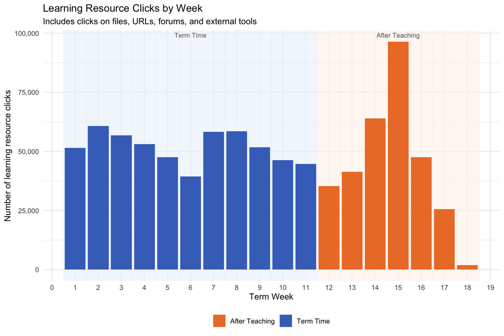

The chart shows a clear two-phase pattern in Moodle engagement across the academic year. During term time (weeks 1–11, shown in blue), resource clicks are consistently high, ranging between approximately 38,000 and 63,000 per week. Activity is highest in weeks 2 and 7–8, both reaching around 60,000 clicks, with a dip in weeks 5–6 (closer to 40,000) that may reflect a mid-term lull or a lighter teaching schedule in those weeks. Weeks 10–11 show a modest decline toward the end of term, and week 12 marks a sharp drop to around 34,000 — the transition out of formal teaching.

After teaching ends (weeks 12 onwards, shown in orange), engagement does not disappear but instead surges dramatically in weeks 14–15, peaking at around 65,000 and 95,000 respectively — levels comparable to or exceeding the busiest teaching weeks. This spike almost certainly reflects students intensively revisiting lecture slides, readings, and assessment guidance in the run-up to examinations and coursework deadlines. Activity then falls steeply in weeks 16–17 (around 45,000 and 25,000) and drops to near zero by week 18, consistent with the end of the assessment period.

One important caveat is that the data were collected on 30 April 2026, only a few weeks after the end of the Term 2 teaching period. For Term 2 modules, the post-teaching period captured in the logs is therefore very short, meaning that post-teaching activity visible in the later weeks is likely dominated by Term 1 modules, for which the full post-teaching window — including the January examination period — was available.

### 3.4.3 Assessment Deadlines and Moodle activity

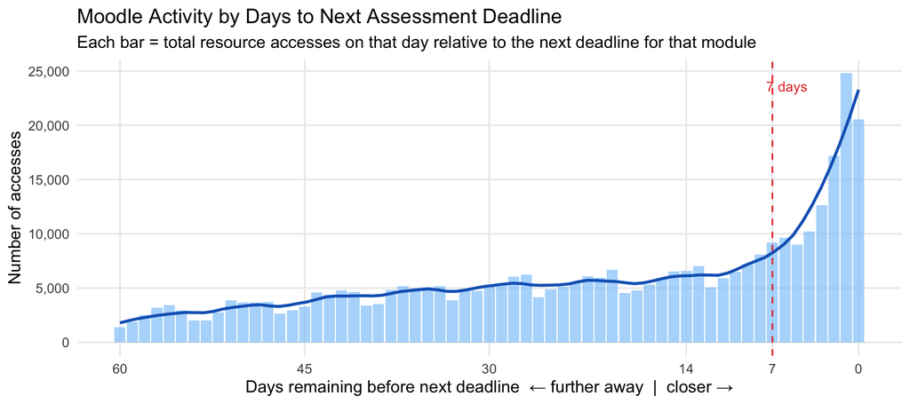

Moodle activity rises markedly as assessment deadlines approach. The LOESS curve reveals a gradual build-up from around 30 days out, a pronounced acceleration in the final two weeks, and a sharp peak in the last 7 days. The dashed red line marks the one-week threshold used to define the *week-before-deadline* dummy variable.

[figure not shown]

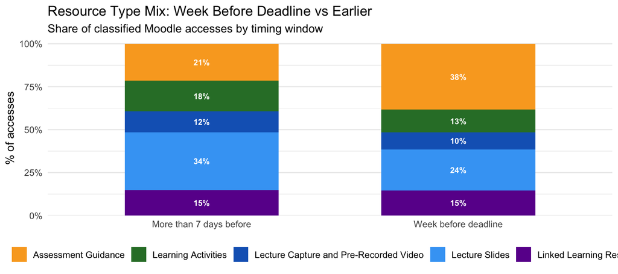

The composition of Moodle activity shifts noticeably in the week before a deadline. **Assessment Guidance** accounts for a substantially larger share of accesses in that final week compared with earlier periods, confirming that students treat it primarily as a last-minute resource. Conversely, **Lecture Slides** and **Learning Activities** each account for a smaller share in deadline week, as students shift from general learning to assessment-focused behaviour.

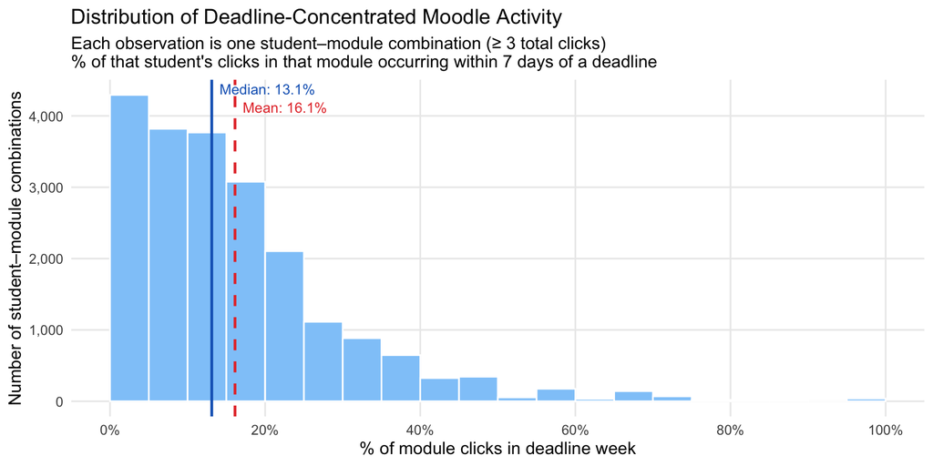

The distribution is strongly right-skewed: the majority of student–module combinations have a low proportion of deadline-concentrated clicks — most Moodle engagement is spread across the term rather than concentrated in assessment run-ups. However, a meaningful tail extends toward 100%, identifying student–module pairs where virtually all Moodle activity occurs within a week of an assessment. Students in that tail are likely using Moodle in a purely instrumental way — accessing materials only when an assessment forces them to — rather than as a regular study tool.

## 3.5 Where do Students Access Moodle resources?

### 3.5.1 On-Campus vs Off-Campus Access by Resource Type

The Moodle activity logs record the IP address of each request, which can be used to infer the approximate geographic location from which students are accessing learning resources. All distinct public IP addresses in the logs are geolocated using the ip-api.com API, which returns country, region, city, and coordinates.

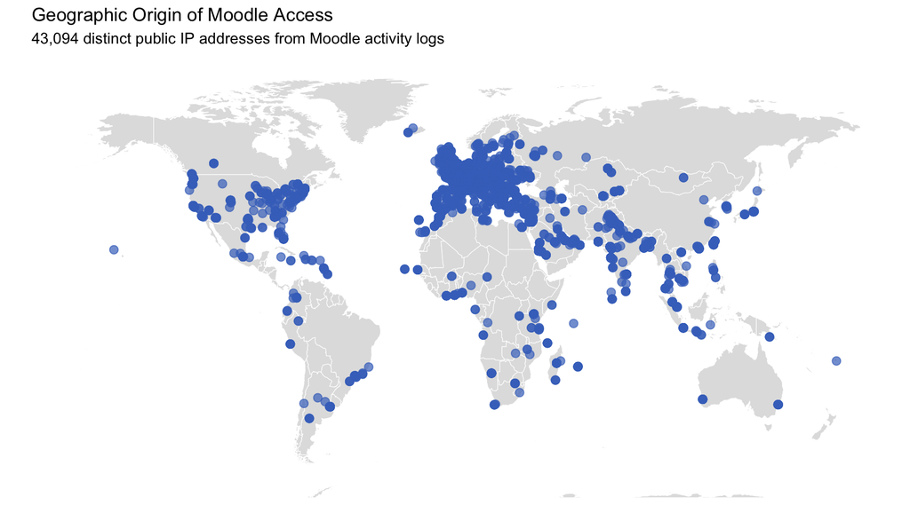

Using this information, an access is classified as **on-campus** if either (a) its geolocated coordinates fall within 1 km of Northampton Square, or (b) the registered organisation or ISP name matches City, University of London. Accesses that meet neither criterion are classified as **off-campus**.

For each individual resource posted in a module, the chart below shows what percentage of students enrolled in that module accessed it from on-campus and what percentage accessed it from off-campus. Each box summarises the distribution of that percentage across all individual resources of a given type across all modules. A resource where 30% of enrolled students clicked it from off-campus contributes a value of 30 to the Off Campus box for its resource type.

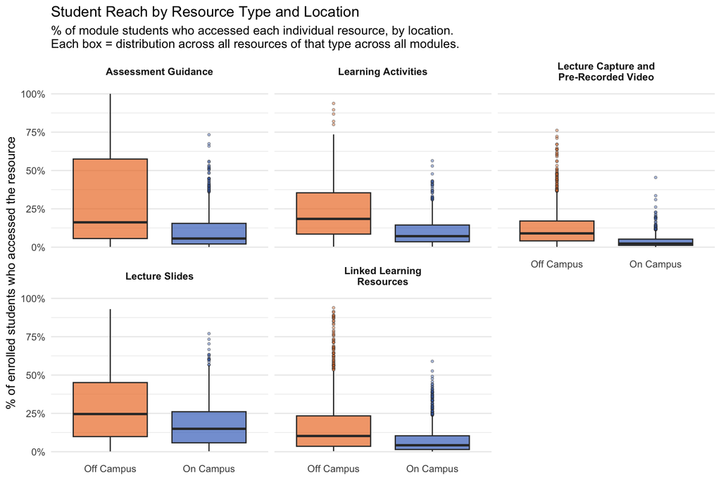

Off-campus access consistently and substantially outpaces on-campus access across every resource type. For all five categories, the orange (off-campus) box sits clearly above the blue (on-campus) box, indicating that a larger share of enrolled students access each individual resource when connecting remotely than when on campus. This pattern is consistent with how students use Moodle in practice: the platform is primarily a resource for independent study outside the classroom, rather than something accessed during or immediately after a session on university premises.

The gap between on-campus and off-campus reach is widest for **Assessment Guidance** and **Learning Activities**, where the off-campus interquartile range extends considerably higher and the median is roughly twice the on-campus median. This makes intuitive sense: students are more likely to consult marking criteria, rubrics, and seminar preparation materials when sitting down to work at home than when moving between campus buildings. **Lecture Slides** show a similar pattern, though the distributions overlap more, suggesting that some students do access slides during or between on-campus sessions. **Linked Learning Resources** and **Lecture Capture and Pre-Recorded Video** have the lowest reach overall in both settings, but the off-campus advantage remains: recordings in particular are accessed by a small share of students in either context, with the on-campus distribution compressed close to zero for most resources.

### 3.5.2 On-Campus vs Off-Campus Access Across the Teaching Term

The chart below tracks the weekly volume of on-campus and off-campus resource clicks across the teaching term and the post-teaching period. Term weeks 1–11 represent the formal teaching period; weeks 12 onwards cover the revision and assessment period after teaching ends.

[figure not shown]

The sharpest divergence comes after teaching ends. Off-campus access surges dramatically in weeks 14–15, peaking at around 70,000 clicks — more than double any single teaching week — before dropping steeply in weeks 16–17. This spike almost certainly reflects students intensively revisiting materials in the run-up to assessments. On-campus access, by contrast, barely registers after week 12, remaining close to zero throughout the post-teaching period. The revision period drives a large spike in remote engagement while campus-based access collapses almost entirely. Students preparing for their exams and coursework deadlines are doing so from home, not from campus.

# 4 Student Engagement Profiles

The preceding sections have examined in-person attendance and Moodle engagement as separate dimensions. Each tells only part of the story: a student who attends every session but rarely opens a resource online has a different learning pattern from one who misses lectures but works systematically through recorded content and practice materials between sessions. Simple binary categories — attending or not, accessing Moodle or not — flatten this diversity and risk designing interventions that miss large groups entirely.

This section brings the two dimensions together in three steps. The first examines the relationship between in-person attendance and online engagement directly, finding a clear positive association — students who attend more also access more resources — but also substantial variation: many student–module combinations sit far from the trend, pointing to genuinely different learning patterns. The second step captures these patterns more formally, using first a threshold-based classification and then a data-driven clustering algorithm to identify groups of students with distinct engagement profiles. The third step deploys statistical models to identify which student characteristics and session factors are associated with each profile, moving from description to explanation.

## 4.1 Moodle Engagement and In-Person Attendance

The previous section documented how students engage with Moodle resources — how many they access, what types they prefer, when they access them, and from where. This first part of the analysis asks what the relationship between that online engagement and students’ physical presence in class looks like. Does more active Moodle use go hand in hand with higher attendance, or do students use online resources as a substitute for missed sessions? And does the association hold equally across departments and across different types of resources?

### 4.1.1 Overall relationship between attendance and Moodle resource access

The first question is whether students who attend more sessions in person also engage more actively with online resources — or whether the two forms of engagement operate as substitutes. The chart below plots each student–module combination by their average in-person attendance (x-axis) against their overall Moodle resource coverage — the share of all resources posted for that module that they accessed at any point during or after the teaching period. The trend line is fitted by LOESS to capture any non-linearity in the relationship.

[figure not shown]

The overall association between in-person attendance and Moodle resource coverage is positive but loose. The trend line rises from left to right, confirming that students who attend more regularly also tend to access more resources online. At the same time, there is substantial scatter around the trend: large numbers of student–module combinations appear in every region of the space, from students highly engaged on both dimensions to those with low engagement across the board, and everything in between.

The aggregate picture conceals an important distinction in *when* students access resources. Moodle engagement during the teaching term — accessing slides, activities, or readings in the weeks classes are running — is plausibly tied to active learning alongside in-person attendance. Moodle access after the teaching period ends, by contrast, is more likely to reflect revision and assessment preparation, driven by deadline pressure rather than regular study habits. The two charts below disaggregate overall coverage by the timing of access.

[figure not shown]

During the teaching term, the trend line slopes clearly upward: as in-person attendance increases, so does the share of resources accessed during those same weeks. The density of observations shifts gradually toward higher Moodle coverage as attendance rises, consistent with a complementary relationship — students who attend more regularly also engage more actively with posted materials. There is no evidence of substitution: students with low attendance do not compensate by accessing more online content while classes are running.

[figure not shown]

After the teaching period ends, the picture changes markedly. The trend line is essentially flat across the full range of attendance values, and the density of observations is concentrated in the same low-resource band regardless of how often the student attended during term. Post-teaching Moodle access is not associated with in-person attendance: both high- and low-attenders draw on course materials at similar rates once lectures have finished. This pattern is consistent with revision and assessment preparation being a near-universal behaviour driven by deadline pressure rather than a continuation of established study habits.

The same patterns hold when examined separately by department.

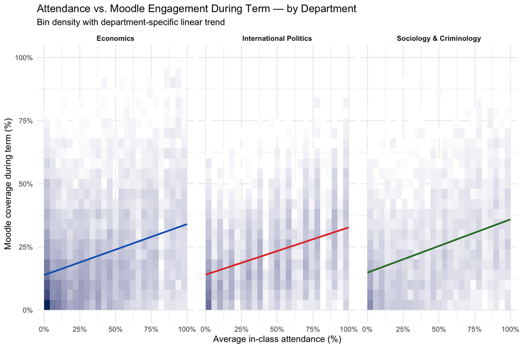

During the teaching term, the positive relationship between attendance and Moodle engagement holds consistently across all three departments. Economics (blue), International Politics (red), and Sociology & Criminology (green) all show a clearly upward-sloping trend line of broadly similar steepness, with no meaningful differences in the strength or direction of the relationship across departments.

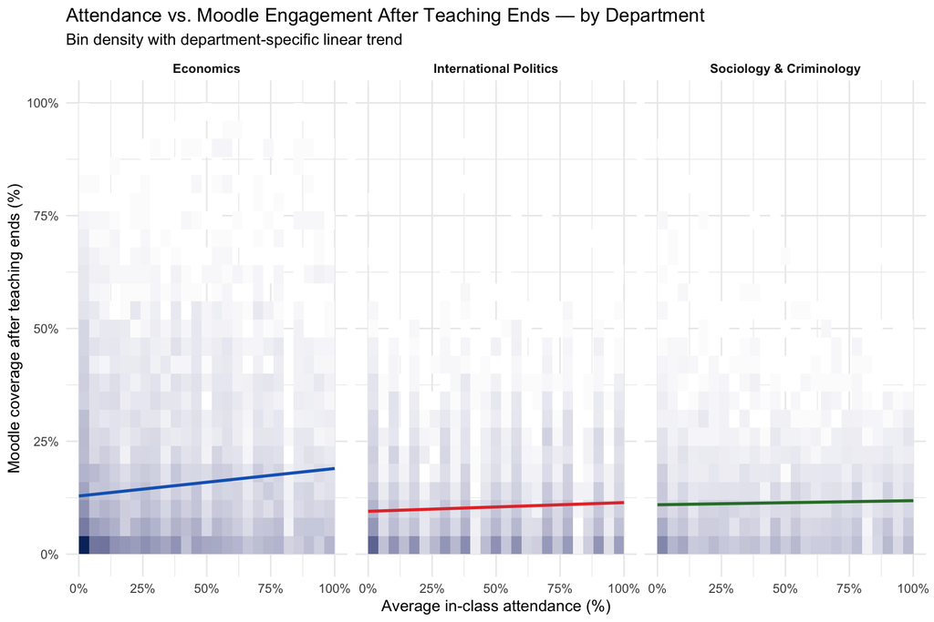

After the teaching period, all three trend lines flatten, confirming that post-teaching Moodle use is unrelated to in-person attendance regardless of department. The pattern is strikingly consistent: the disengagement from the attendance–Moodle relationship after term ends is not specific to any one department but a shared feature of how students across SPGA approach revision and assessment preparation.

### 4.1.2 Resource Type Differences in Attendance–Engagement Relationship

We can then break the overall attendance–engagement relationship down by resource type. This reveals important differences both in the *level* of access and in the *slope* of its relationship with attendance.

**Assessment Guidance** has the highest base level of any resource type: even students with very low attendance access around 40–50% of assessment materials, and the dense concentration of observations in the upper half of the y-axis is visible across the full range of attendance values. The trend line shows a gentle positive slope, rising from roughly 45% to 50% as attendance increases. Students engage with marking criteria, rubrics, and assignment briefs regardless of how often they attend, while the shallow slope suggests that more regular attenders access marginally more of this material.

**Learning Activities** show the steepest positive slope of any resource type, with the trend line rising from around 35% at zero attendance to over 60% at full attendance. This is the clearest evidence of complementarity in the data: students who show up to sessions are also far more likely to engage with seminar preparation materials, worksheets, and guided tasks. The density of observations is spread across the full y-range, with a visible concentration at 100% access among high-attenders.

**Lecture Capture and Pre-Recorded Video** — covering both live session captures and pre-recorded instructional video packages — have the flattest trend line of all resource types, hovering around 40% regardless of attendance level. The density of observations is distributed uniformly across all attendance values, with no sign of a substitution effect: students who miss sessions are not accessing recordings at higher rates than those who attend regularly. Recordings appear to be used opportunistically across all attendance profiles rather than as a systematic catch-up mechanism.

**Lecture Slides** show a moderate positive slope, rising from around 45% at low attendance to around 65% at high attendance, making them the resource type most consistently accessed by regular attenders after Learning Activities. The density is concentrated in the upper half of the y-axis, consistent with slides being a reference resource used broadly but more intensively by students who attend.

**Linked Learning Resources** show a shallow positive slope at a lower base level, rising from around 30% to 40%. The density is spread across the full range of access values, with many observations near zero and a visible cluster at higher values. Students are selective about external readings, and the relationship with attendance — while positive — is weaker than for session-linked materials.

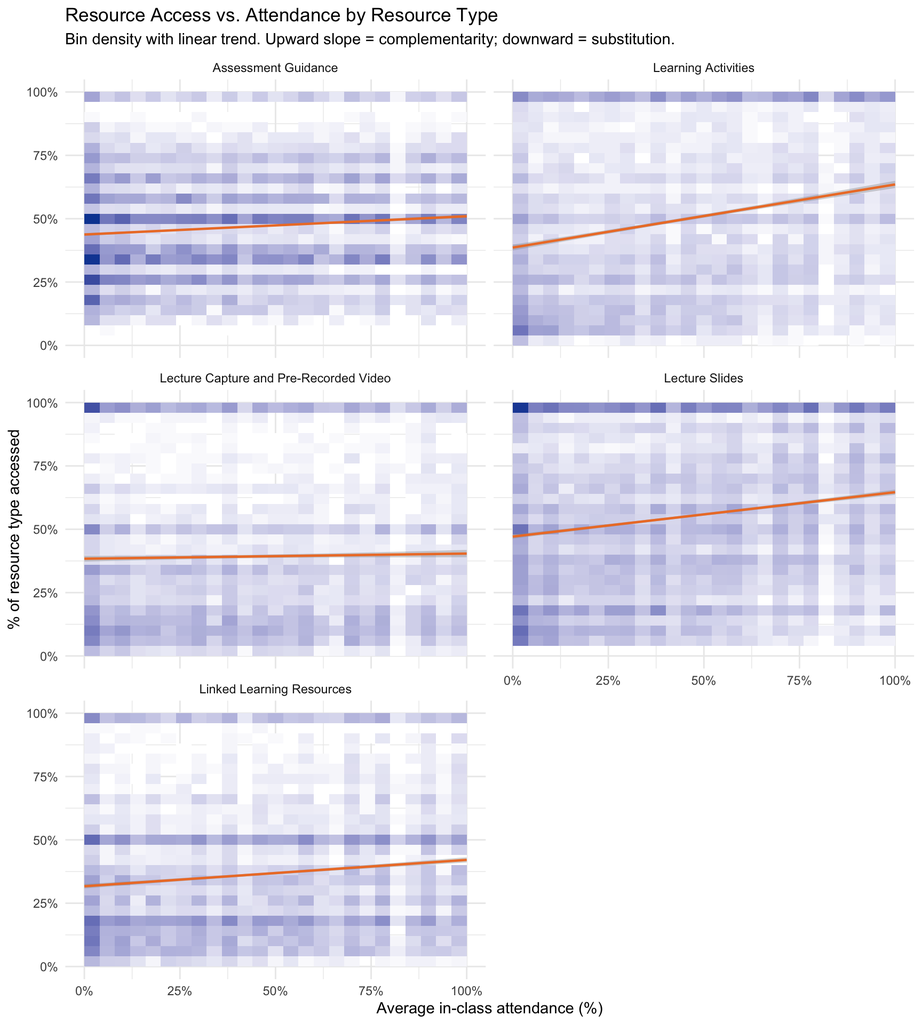

## 4.2 Identifying Profiles Using Engagement Thresholds

The scatter makes clear that the overall association between attendance and Moodle coverage is real but loose. Large numbers of student–module combinations appear in every region of the space: students who are active both in person and online, students who attend but barely touch the digital resources, students with low attendance but high Moodle coverage, and a substantial mass with minimal engagement on both dimensions. This heterogeneity calls for a more systematic approach to identifying distinct engagement profiles.

A straightforward way to build engagement profiles from two dimensions — in-person attendance and online resource access — is simply to divide students according to whether their engagement on each dimension is high or low. Applying a threshold to both dimensions simultaneously produces four possible categories: students who engage actively on both (**Actively Engaged**), those who attend but make little use of online resources (**In-Person Only**), those who access resources online but attend infrequently (**Online-Focused**), and those with low engagement on both dimensions (**Limited Engagement**).

The approach is transparent and requires no modelling assumptions, but its conclusions depend on where the thresholds are set — and there is no reason the cut-off for attendance and the cut-off for Moodle coverage need to be the same. The interactive explorer below makes this dependence visible: the two sliders independently control the attendance threshold and the Moodle coverage threshold, re-drawing the classification boundary in real time and updating the group sizes. Both default to 33%, representing students who attended or accessed fewer than one-in-three scheduled sessions or available resources.

[interactive chart not shown]

What counts as sufficient engagement depends on the expectations attached to each dimension — and those expectations differ. For in-person attendance the standard is relatively clear: students are expected to attend all scheduled sessions, so any meaningful absence represents a shortfall. For Moodle coverage, the picture is murkier: the right threshold depends on how many resources are available on a given module, which types they are, and how much students are expected to engage with them independently. A module that posts only slides may warrant a different standard from one that hosts readings, practice exercises, and pre-recorded content. Adjusting the two sliders independently reflects this asymmetry, and varying them changes the relative size of the four groups considerably — which itself reveals how sensitive the classification is to assumptions that are rarely made explicit.

Yet even with the thresholds calibrated carefully, coverage alone captures only one dimension of online engagement. The earlier analysis of Moodle behaviour showed that students vary substantially not just in *how much* they access — but in *when* they do so, *how regularly* across the term, and *from where*. A student who accesses every resource in the final week before an assessment looks identical to one who works through them consistently week by week, yet these represent very different learning patterns. The next section addresses this limitation by moving away from fixed thresholds and instead using a data-driven clustering approach that incorporates timing, regularity, and location alongside raw coverage.

## 4.3 Engagement Profiles from Cluster Analysis

To capture the full range of engagement dimensions identified earlier — not just how much students engage, but when, how consistently, and from where — we use k-means clustering, an algorithm that automatically groups students into a pre-specified number of clusters by finding combinations that are as similar as possible within each group and as different as possible across groups. The algorithm is applied to six dimensions simultaneously: total Moodle coverage, number of weeks active during the term, in-person attendance, the share of Moodle activity occurring before assessment deadlines, the share occurring after the teaching period ends, and the proportion of accesses made from campus. All variables are standardised before clustering so that each dimension contributes equally regardless of scale.

K-means requires a pre-specified number of clusters. To decide how many to use, we first applied a data-driven approach based on the silhouette score — a measure of how well each student–module combination fits its assigned cluster relative to the nearest alternative. This method pointed firmly to k = 2 as the statistically optimal solution, an unsurprising result given the strong binary structure in the data: the dominant axis separating high-engagement from low-engagement students is so pronounced that any purely statistical criterion will recover it first and treat finer-grained differences as noise. A two-cluster solution, however, captures none of the variety in *how* students engage — only whether they do. We therefore explored solutions with progressively higher values of k, examining the characteristics of each cluster set manually to assess whether the additional groups corresponded to recognisable and interpretable patterns of behaviour. Six clusters emerged as the most informative solution: it produces distinct, meaningful profiles rather than arbitrary subdivisions of a single engagement continuum. The result is not the most statistically parsimonious, but it is the one that best reflects the genuine diversity of student learning styles in the data.

The map below shows where each profile sits in the two-dimensional space of in-person attendance and Moodle coverage, giving an immediate sense of how the clusters divide the engagement landscape before examining them in detail.

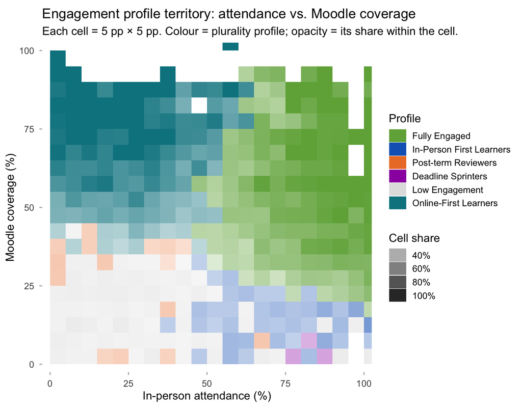

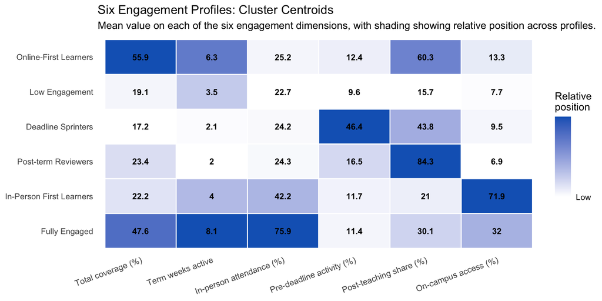

The heatmap confirms the six profiles described below. Each is defined by its pattern across the six dimensions rather than by any single indicator.

**Fully Engaged** — The highest in-person attendance (75.9%) and the most weeks active during the term (8.1), coupled with strong Moodle coverage (47.6%). These students complement regular attendance with consistent online activity spread across the teaching period and represent the most comprehensively engaged profile in the data.

| Students (%) | Total coverage (%) | Term weeks active | Attendance (%) | Pre-deadline (%) | Post-teaching share (%) | On-campus access (%) |
| --- | --- | --- | --- | --- | --- | --- |
| 4,411 (20.7%) | 47.6 | 8.1 | 75.9 | 11.4 | 30.1 | 32.0 |

**Online-First Learners** — The highest Moodle coverage of any profile (55.9%) combined with dramatically lower in-person attendance (25.2%). Crucially, they are active across more than six weeks of the teaching term — they engage with course content consistently throughout the term, just not in person. Their access is almost entirely off-campus (only 13.3% on-campus), and they continue to access resources after the teaching period ends (60.3% post-teaching share), but this reflects a continuation of an already high-engagement pattern rather than a last-minute catch-up. These students have substituted regular online study for in-person attendance.

| Students (%) | Total coverage (%) | Term weeks active | Attendance (%) | Pre-deadline (%) | Post-teaching share (%) | On-campus access (%) |
| --- | --- | --- | --- | --- | --- | --- |
| 3,279 (15.4%) | 55.9 | 6.3 | 25.2 | 12.4 | 60.3 | 13.3 |

**In-Person First Learners** — Moderate overall Moodle coverage (22.2%), but the highest on-campus access proportion of any profile (71.9%). These students are physically present and engage with resources while on site, but their online engagement does not extend far into independent study beyond the classroom setting.

| Students (%) | Total coverage (%) | Term weeks active | Attendance (%) | Pre-deadline (%) | Post-teaching share (%) | On-campus access (%) |
| --- | --- | --- | --- | --- | --- | --- |
| 2,844 (13.3%) | 22.2 | 4.0 | 42.2 | 11.7 | 21.0 | 71.9 |

**Post-term Reviewers** — Low activity during term — around a quarter of resources accessed and active for only two weeks — but the highest post-teaching share of any profile (84.3%). These students are largely inactive while lectures are running and then work intensively through course materials once the teaching period ends, most likely in preparation for assessments.

| Students (%) | Total coverage (%) | Term weeks active | Attendance (%) | Pre-deadline (%) | Post-teaching share (%) | On-campus access (%) |
| --- | --- | --- | --- | --- | --- | --- |
| 3,916 (18.3%) | 23.4 | 2.0 | 24.3 | 16.5 | 84.3 | 6.9 |

| Students (%) | Total coverage (%) | Term weeks active | Attendance (%) | Pre-deadline (%) | Post-teaching share (%) | On-campus access (%) |
| --- | --- | --- | --- | --- | --- | --- |
| 2,122 (9.9%) | 17.2 | 2.1 | 24.2 | 46.4 | 43.8 | 9.5 |

**Low Engagement** — Low values across all dimensions — around 19% coverage, 3.5 active weeks, and 23% attendance — but without the concentrated timing bursts that distinguish Deadline Sprinters or Post-term Reviewers. Both the pre-deadline (9.6%) and post-teaching (15.7%) shares are the lowest of any profile, suggesting that even assessment pressure fails to prompt meaningful engagement with course resources.

| Students (%) | Total coverage (%) | Term weeks active | Attendance (%) | Pre-deadline (%) | Post-teaching share (%) | On-campus access (%) |
| --- | --- | --- | --- | --- | --- | --- |
| 4,783 (22.4%) | 19.1 | 3.5 | 22.7 | 9.6 | 15.7 | 7.7 |

The relative prevalence of each profile across all student–module combinations is shown below.

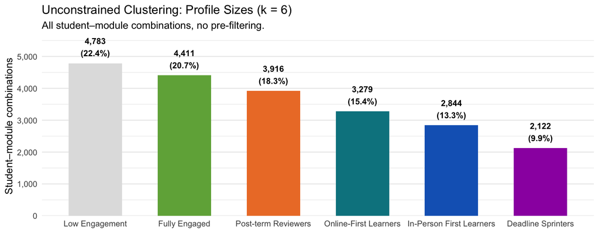

## 4.4 Correlates of Engagement Profiles

The previous section describes the six engagement profiles. This section investigates what student characteristics predict membership of each profile, using the same student-level covariates as the attendance analysis: cohort level, department, gender, disability status, ethnicity, visa status, entry via Clearing, distance from campus, area deprivation (IMD decile), and prior academic performance. Models are estimated at the student–module level, with a random intercept for student to account for the fact that the same student appears across multiple modules.

The analysis proceeds in two steps. The first focuses on the two extremes of the engagement spectrum — **Low Engagement** and **Fully Engaged** — using parallel binary logistic regressions that ask which student characteristics predict membership of each pole versus all other profiles. The second step uses a **multinomial logistic regression** to map each predictor across all six profiles simultaneously, summarised in a table that shows, for each student characteristic, which profiles it is associated with.

### 4.4.1 Determinants of Disengagement and Full Engagement

Predictors are grouped by category and, within each group, ordered by their association with Low Engagement. Filled points indicate p < 0.05; open points are non-significant. An odds ratio above 1 means the characteristic is associated with *higher* odds of that outcome; below 1 means lower odds.

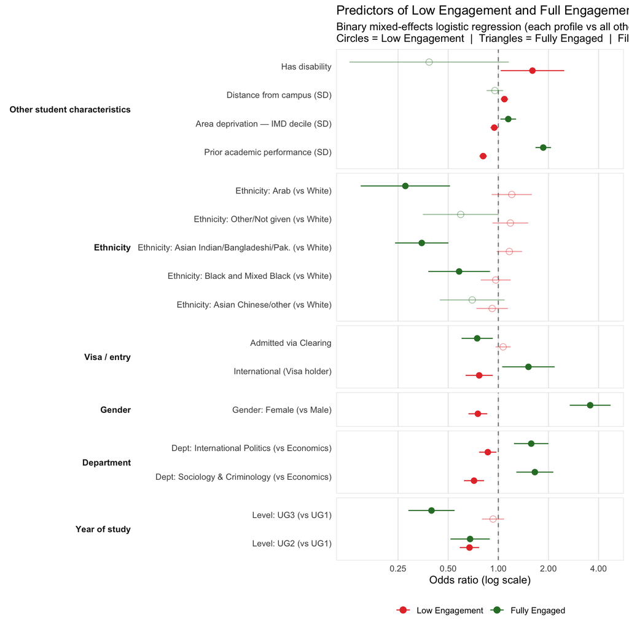

### 4.4.2 Engagement Profile Predictors: Summary Table

The table below summarises the multinomial logistic regression results across all five non-baseline profiles (versus **Low Engagement** as the reference category). Each cell shows the direction and significance of the association for a given predictor and profile. A significant positive association (↑) means that students with that characteristic are more likely to be in that profile than in Low Engagement; a significant negative association (↓) means they are less likely.

[output not shown]

### 4.4.3 Patterns by Predictor Group

**Department.** Both non-Economics departments show significantly lower odds of Low Engagement and higher odds of Fully Engaged in the binary logit — but the multinomial reveals that the two departments achieve this through strikingly different engagement styles. International Politics students shift strongly toward Online-First Learners (↑***) and Deadline Sprinters (↑***) and away from In-Person First (↓***) — a pattern of high but asynchronous and assessment-concentrated engagement. Sociology & Criminology students show the opposite: more Fully Engaged (↑***) and marginally more In-Person First, less Online-First (↓***), Post-term, and Deadline Sprinters — a consistently present, in-person-centred engagement style. Economics emerges as the department with the most assessment-reactive and disengaged profiles relative to both.

**Ethnicity.** The clearest signal from the binary logit is that Arab, Asian Indian/Bangladeshi/Pakistani, and Black and Mixed Black students all have significantly lower odds of being Fully Engaged than White students — while none of the groups show significantly higher odds of Low Engagement. The differences between ethnic groups therefore lie primarily in where students concentrate within the middle profiles rather than in a simple engaged/disengaged split.